# Gradient Boost For Classification

Gareth Bayvel

# Random Forest Refresher

### Building an Random Forest:

**Step One:**

1. Create a Decision Tree with our bootstrapped dataset.
1. To get more variability in our trees, only consider a random subset of explanatory variables at each step.

**Step Two:**

1. Repeat Step One n number of times to build a forest of decision trees.

**Step Three:**  
Estimate the accuracy of the random forest:

- We can now use our Out-of-Bag data as "Unseen Data" to test our RandomForest and measure its accuracy by the proportion of correctly classified OOB samples.
- Our Out-of-Bag error is our proportion of wrong classifications.
- We can no go back to step one bulding a random Forest and instead of using two random columns we can compare the Out-of-Bag error for different number of variables per step.

**Step Four:**  
Select most accurate random forest based upon Out-of-Bag error.

**Important Notes:**

1. Each tree has equal say and are not weighted.
1. Each tree is independent of one another.
1. Trees are usually full length or greater than just a stump (node and two leaves).

```python
Image('RFboost.png')
```

[figure not shown]

## Adaboost Refresher

### Building an AdaBoost Forest:

**Step One:** A first base classifier is trained and used to make predictions on the training set. The relative weight of misclassified training instances is then increased.

**Step Two:**  
A second classifier is trained using the updated weights and again it makes predictions on the training set, weights are updated, and so on.

**Important Notes:**

1. Adaboost Forests are usually just stumps
1. Stumps are trees with a node and two leaves
1. These are weak learners
1. Unlike RF, with Adaboost some stumps are weighted in terms of voting
1. Unlike RF where each tree is independent, with Adaboost order is important
1. By paying more attention to the training instances that the predecessor underfitted a new predictor can correct its predecessor. Resultantly, new predictors focuse more and more on the hard cases.

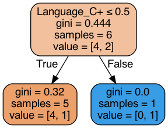

```python
Image('RootNode.png')
```

# Gradient Boosting

Instead of tweaking the instance weights at every iteration like AdaBoost does, this method tries to fit the new predictor to the residual errors made by the previous predictor.

#### Notably: Gradient Boosting Tree's are Usually larger than a stump but tree size is still restricted (max leaves between 8 and 32)

# Gradient Boosting For Classification

When Gradient Boosting is Used for Classification it has alot in Common with Logistic Regression so be sure to go over my Logistic Regression module. Instead of tweaking the instance weights at every iteration like AdaBoost does, this method tries to fit the new predictor to the residual errors made by the previous predictor.

### Building A Gradient Boosting Forest:

**Step One**:

1. Gradient Boost starts by making a single leaf which is an initial guess for our dependant variable.
1. When we use Gradient Boosting for Classification the initial Prediction for every individual is the log(odds).
1. This Initializes our Model with a constant value (Initial Leaf).

**Step Two**:

1. Converting log(odds) into a probabilty with the Logistic function.
1. The easiest way to use log(odds) for classification is to convert it to a probabilty with the Logistic function.
1. Calculate the residuals (pseudo-residuals) between our actual observations and our predicted value (initial guess in probability form).
1. Fit a regression tree to the residuals (pseudo-residuals) for each Tree we construct.
1. Calculate the output values of each leaf.
1. Make a New Prediction for each sample and Update residuals accordingly

**Step Three**:

1. Repeat the above steps.
1. Our second tree is built based on the residual errors of the first tree.

# Gradient Boost algorithm

#### To solve any supervised Machine Learning problem, given the dataset:

$$\{(x_i,y_i\}_{i=1}^{n}$$

#### And a Differential Loss Function:

$$L(y,f)$$

#### We are trying to find the values of our parameters than minimize our differentiable loss function:

$$\hat f(x) = argmin\sum_{i=1}^{n}[L(y,f(x))]$$

## **Step One**:

#### Initialize Model with A constant Value

$$\hat F_0(x) = \operatorname*{arg\,min}_\gamma\sum_{i=1}^{n}[L(y_i,\gamma)]$$

## **Step Two**:

#### For each Tree we want to construct

For m = 1 to M (number of trees we want to make):

#### A. Compute:

$$ r_{im} = -[\frac{\partial L(y_i,f(x_i))}{\partial f(x_i)}]_{F(x)=F_{m-1}(x)}$$

Where:

- $r_{im}$ is the residual (r)
- for the $i^{th}$ (i) sample
- in the $m^{th}$ tree

#### B. Fit a regression tree to the $r_{im}$ values

Create terminal regions $R_{jm}$ for $j = 1...j_m$

- So we create a regression tree to predict the residuals where our leaves in our new trees are our $R_{jm}$ where j is the index of that leaf and m is the tree

#### C. Output values for each leaf

1. For $j = 1..j_m$ compute: $$\gamma_{jm} = argmin\sum_{x_i\in R_{ij}}{} L(y_i, F_{m-1}(x_i)+\gamma)$$

We are trying to find a $\gamma$ that minimizes the formula above

- ${x_i\in R_{ij}}$ selects only the samples within a specific leaf.

#### D. Updating rule

$$F_m(x) = F_{m-1}(x) + \nu \sum_{j=1}^{J_m} \gamma_{jm}I(x \in R_{jm})$$

where: $\nu$: our learning rate

Sum up all the output values $\gamma_{jm}$ for all the leaves that our x can be found in or is a member of. $$\sum_{j=1}^{J_m} \gamma_{jm}I(x \in R_{jm})$$

## Step Three:

#### Output Final Prediction

$$F_m(x)$$

# Worked Example

#### Data Scientist Job Acceptance $\{(x_i,y_i\}_{i=1}^{n}$

$$\begin{array}{c|c} Masters & Age & Language & Accepted\\ \hline Yes & 22 & Python & Yes\\ \hline Yes & 57 & R &Yes\\ \hline No & 44 & Python &No\\ \hline Yes & 29 & C+ & No\\ \hline No & 32 & R &Yes\\ \hline No & 24 & Python & Yes \end{array}$$

# This Part dives deep into the maths and is easily Illustrated at the Next Skip Point

### A Loss Function:

$$\text{log(likelihood) of observed data given prediction} = \sum_{i=1}^{m}y_{i}log(p)+(1-y_i)log(1-p)$$

Where:

- p refers to the predicted probability 0.667 (see plot below)
- $y_{i}$ refers to the observed values for **Accepted**
- Accepted $y=1$
- Not Accepted $y=0$ $$$$

$$ \begin{cases} log(p) & \quad \text{if } y = 1\\ log(1-p) & \quad \text{if } y = 0 \end{cases} $$

### Log Likelihood For our Examples

**Accepted**: $$1\times log(0.667)+(1-1)log(1-0.667) = log(0.667)$$

**Not Accepted**: $$0\times log(0.667)+(1-0)log(1-0.667) = log(1-0.667)$$

#### All Examples

$$log(0.667) + log(0.667) + log(0.667) + log(0.667) + log(1-0.667) + log(1-0.667)$$

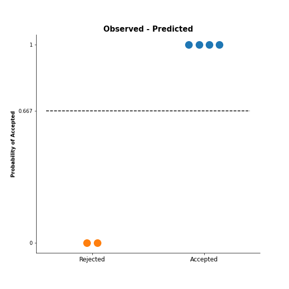

```python
Image('logLikelihood.png')
```

### Goal is to Maximize log Likelihood

If we want to use the log likelihood as a Loss Function its better to use the negative log likelihood instead

$$-\sum_{i=1}^{m}y_{i}log(p)+(1-y_i)log(1-p)$$

#### In terms of our Data

$$-[\text{Observed}\times log(p)+(1-\text{Observed})log(1-p)]$$

**Step One:**

$$-\text{Observed}\times log(p)-(1-\text{Observed})log(1-p)$$

**Step Two:** $$-(1-\text{Observed})log(1-p) = -log(1-p) + \text{Observed} \times log(1-p)$$

$$-\text{Observed}\times -log(1-p) + \text{Observed} \times log(1-p)$$

**Step Three:**

$$-\text{Observed}\times [log(p)-log(1-p)] - log(1-p)$$

**Step Four:** $$[log(p)-log(1-p)] = \frac{log(p)}{log(1-p)} = log\frac{p}{1-p} = log(odds)$$

$$-\text{Observed}\times log(odds) - log(1-p)$$

**Step Five:** $$log(1-p) = -log(1+e^{log(odds)}) $$

### Loss Function

$$-\text{Observed}\times log(odds) + log(1+e^{log(odds)})$$

### A Differentiable Loss Function:

#### Partial Derivative w.r.t log(odds)

$$\frac{\partial L}{\partial \text{log(odds)}} = -\text{Observed}\times log(odds) + log(1+e^{log(odds)})$$

**First Part** $$\frac{\partial L}{\partial \text{log(odds)}} = -\text{Observed}\times log(odds)$$

$$= -\text{Observed}$$

**Second Part** $$\frac{\partial L}{\partial \text{log(odds)}} = -log(1+e^{log(odds)})$$

**Using the Chain Rule** $$\frac{\partial L}{\partial \text{log(odds)}} = \frac{1}{1+e^{log(odds)}} \times e^{log(odds)} = \frac{e^{log(odds)}}{1+e^{log(odds)}}$$

## Partial Derivative w.r.t log(odds)

$$\frac{\partial L}{\partial \text{log(odds)}} = -\text{Observed}+ \frac{e^{log(odds)}}{1+e^{log(odds)}}$$

## **Step One**:

#### Initialize Model with A constant Value

$$\hat F_0(x) = \operatorname*{arg\,min}_\gamma\sum_{i=1}^{n}[L(y_i,\gamma)]$$

#### Find $\gamma$ that Minimizes the Sum below

$$\begin{align} \gamma &= -1\times log(odds) + log(1+e^{log(odds)}) \nonumber \\ &\qquad {} -1\times log(odds) + log(1+e^{log(odds)})\nonumber \\ &\qquad {} - 0\times log(odds) + log(1+e^{log(odds)}) \nonumber \\ &\qquad {} -0\times log(odds) + log(1+e^{log(odds)})\nonumber \\ &\qquad {} - 1\times log(odds) + log(1+e^{log(odds)}) \nonumber \\ &\qquad {} - 1\times log(odds) + log(1+e^{log(odds)}) \end{align} $$

#### Find $\gamma$ By Taking the Partial Derivative of Our Loss Function and Setting Equal to Zero

$$\begin{align} \gamma &= -1+ \frac{e^{log(odds)}}{1+e^{log(odds)}} \nonumber \\ &\qquad {} -1+ \frac{e^{log(odds)}}{1+e^{log(odds)}}\nonumber \\ &\qquad {} - 0+ \frac{e^{log(odds)}}{1+e^{log(odds)}} \nonumber \\ &\qquad {} -0+ \frac{e^{log(odds)}}{1+e^{log(odds)}}\nonumber \\ &\qquad {} - 1+ \frac{e^{log(odds)}}{1+e^{log(odds)}} \nonumber \\ &\qquad {} - 1+ \frac{e^{log(odds)}}{1+e^{log(odds)}} = 0 \end{align}$$

#### Find $\gamma$ By Taking the Partial Derivative of Our Loss Function and Setting Equal to Zero

$$\begin{align} \gamma &= -1+ \frac{e^{log(odds)}}{1+e^{log(odds)}} \nonumber \\ &\qquad {} -1+ \frac{e^{log(odds)}}{1+e^{log(odds)}}\nonumber \\ &\qquad {} - 0+ \frac{e^{log(odds)}}{1+e^{log(odds)}} \nonumber \\ &\qquad {} -0+ \frac{e^{log(odds)}}{1+e^{log(odds)}}\nonumber \\ &\qquad {} - 1+ \frac{e^{log(odds)}}{1+e^{log(odds)}} \nonumber \\ &\qquad {} - 1+ \frac{e^{log(odds)}}{1+e^{log(odds)}} = 0 \end{align}$$

#### Replace log(odds) with p

$$\begin{align} \gamma &= -1+ p\nonumber \\ &\qquad {} -1+ p\nonumber \\ &\qquad {} - 0+ p\nonumber \\ &\qquad {} -0+ p\nonumber \\ &\qquad {} - 1+ p \nonumber \\ &\qquad {} - 1+ p = 0 \end{align}$$

$$6\times \text{p} = 1 + 1 + 1 + 1$$

$$\text{p} = \frac{4}{6} = 0.667$$

$$$$

This makes Sence because 4 out of the 6 got accepted

#### Predicted Probability into Log(odds)

$$\text{Log(odds)} = log(\frac{p}{1-p})$$$$log(\frac{0.667}{1-0.667}) = 0.6931 $$

# Skip Point

This Whole Mathematical Illustration above is Simply Exampled Below

## Initial Prediction is the log(odds)

When we use Gradient Boosting for Classification the initial Prediction for every individual is the log(odds)

$$\begin{array}{c|c} Masters & Age & Language & Accepted\\ \hline {\color{blue}{Yes}} & {\color{blue}{22}} & {\color{blue}{Python}} & {\color{blue}{Yes}}\\ \hline {\color{blue}{Yes}} & {\color{blue}{57}} & {\color{blue}{R}} & {\color{blue}{Yes}}\\ \hline {\color{orange}{No}} & {\color{orange}{44}} & {\color{orange}{Python}} & {\color{orange}{No}}\\ \hline {\color{orange}{Yes}} & {\color{orange}{29}} & {\color{orange}{C+}} & {\color{orange}{No}}\\ \hline {\color{blue}{No}} & {\color{blue}{32}} & {\color{blue}{R}} & {\color{blue}{Yes}}\\ \hline {\color{blue}{No}} & {\color{blue}{24}} & {\color{blue}{Python}} & {\color{blue}{Yes}} \end{array}$$

#### Calculate the overall log(odds) that someone got the job

Since 4 people in the training set got the job and two did not the log(odds) that someone got the job is: $$$$$$\text{Initial Leaf} = log(\frac{4}{2}) = 0.6931$$

#### Converting log(odds) into a probabilty with the Logistic function

The easiest way to use log(odds) for classification is to convert it to a probabilty with the Logistic function.

The probability that someone got the job is: $$$$

$$\frac{e^{log(odds)}}{1+e^{log(odds)}} = \frac{e^{log(\frac{4}{2})}}{1+e^{log(\frac{4}{2})}} = 0.667$$

# **Step Two**:

#### For each Tree we want to Construct

#### A. Compute:

$$ r_{im} = -[\frac{\partial L(y_i,f(x_i))}{\partial f(x_i)}]_{F(x)=F_{m-1}(x)}$$

#### The middle function is just the partial derivative w.r.t log(odds) which we calculated above:

$$\frac{\partial L(y_i,f(x_i))}{\partial \text{log(odds)}} = -\text{Observed}+ \frac{e^{log(odds)}}{1+e^{log(odds)}}$$

$$ r_{im} = (Observed-Predicted)_{F(x)=F_{m-1}(x)}$$

### Where m is our first tree

$$(Observed - F_{m-1}(x))$$

$$m = 1$$

# Initial Prediction Accuracy Through Pseudo-Residuals

We can measure how bad our initial Prediction is by calculating the pseudo-residuals, the difference between the observed and predicted.

$$\text{Residuals} = (\text{Observed - Predicted})$$

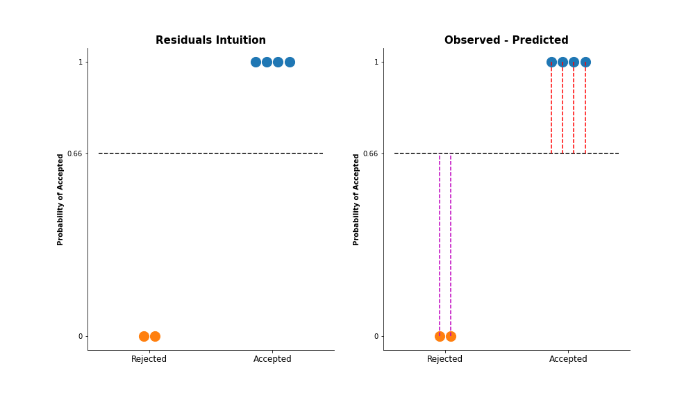

```python
Image('GBLogreg.png')
```

### Residuals for the leaf's Initial Prediction

#### Data Scientist Job Acceptance

$$\begin{array}{c|c} Masters & Age & Language & Accepted & Residuals\\ \hline Yes & 22 & Python & Yes & 0.333\\ \hline Yes & 57 & R &Yes& 0.333\\ \hline No & 44 & Python &No& -0.667\\ \hline Yes & 29 & C+ & No & -0.667\\ \hline No & 32 & R &Yes& 0.333\\ \hline No & 24 & Python & Yes & 0.333 \end{array}$$

#### B. Fit a regression tree to the Residual values

We will build our tree using our Master, Age, amd Language to predict the **residuals**.

1. Just for illustration purposes as GB trees are note usually stumps.
1. Below shows Language C+ is the best separator for our Root Node as it has the lowest MSE.

### Mean Squared Error

#### Data Scientist Job Acceptance

$$\begin{array}{c|c} & Residuals & Mean & (\text{Mean-Residuals})^2\\ \hline & 0.333 & -0.002 & 0.112\\ \hline & 0.333& -0.002& 0.112\\ \hline & -0.667& -0.002& 0.442\\ \hline & -0.667& -0.002 & 0.442\\ \hline & 0.333& -0.002 & 0.112\\ \hline & 0.333& -0.002 & 0.112\\ \hline Sum & & & 1.33\\ \hline MSE & & & {\color{red}{0.222}} \end{array}$$

## Building A Tree using Masters, Age, and Language to Predict Residuals

## Variable Split (Just A Few Examples)

#### Masters_Yes

$$\begin{array}{c|c} & Masters & Residuals& Mean & (\text{Mean-Residuals})^2\\ \hline &Yes & 0.333 & -0.003 & 0.113\\ \hline &Yes &0.333 & -0.003 & 0.113\\ \hline &Yes & -0.667 & -0.003 & 0.44\\ \hline Sum & & & & 0.666\\ \hline MSE & & & & {\color{red}{0.222}} \end{array}$$

#### Masters_No

$$\begin{array}{c|c} & Masters & Residuals& Mean & (\text{Mean-Residuals})^2\\ \hline &No & 0.333 & -0.003 & 0.113\\ \hline &No &0.333 & -0.003 & 0.113\\ \hline &No & -0.667 & -0.003 & 0.44\\ \hline Sum & & & & 0.666\\ \hline MSE & & & & {\color{red}{0.222}} \end{array}$$

$$\text{Weighted Average} = \frac{3}{3+3}0.22+ \frac{3}{3+3}0.22 $$

$$= 0.22 $$

#### C+

$$\begin{array}{c|c} & Language & Residuals& Mean & (\text{Mean-Residuals})^2\\ \hline &C+ & -0.667 & -0.667 & 0\\ \hline Sum & & & & 0\\ \hline MSE & & & & {\color{red}{0}} \end{array}$$

#### Other

$$\begin{array}{c|c} & Language & Residuals& Mean & (\text{Mean-Residuals})^2\\ \hline &Python & -0.667 & 0.133 & 0.64\\ \hline &R &0.333 & 0.133 & 0.4\\ \hline &Python & 0.333 & 0.133 & 0.4\\ \hline &R &0.333 & 0.133 & 0.4\\ \hline &Python & 0.333 & 0.133 & 0.4\\ \hline Sum & & & & 0.8\\ \hline MSE & & & & {\color{red}{0.16}} \end{array}$$

$$\text{Weighted Average} = \frac{1}{1+0}0+ \frac{5}{5+1}0.16 $$

$$= 0.13 $$

#### 26.5 $\leq$

$$\begin{array}{c|c} & Age & Residuals& Mean & (\text{Mean-Residuals})^2\\ \hline &22 & 0.333 & 0.333 & 0\\ \hline &24 & 0.333 & 0.333 & 0\\ \hline Sum & & & & 0\\ \hline MSE & & & & {\color{red}{0}} \end{array}$$

#### 26.5 $\geq$

$$\begin{array}{c|c} & Age & Residuals& Mean & (\text{Mean-Residuals})^2\\ \hline &29 & -0.667 & -0.167 & 0.25\\ \hline &32 &0.333 &-0.167 & 0.25\\ \hline &44 & -0.667 & -0.167 & 0.25\\ \hline &57 &0.333 & -0.167& 0.25\\ \hline \hline Sum & & & & 1\\ \hline MSE & & & & {\color{red}{0.25}} \end{array}$$

$$\text{Weighted Average} = \frac{2}{2+4}0+ \frac{4}{4+2}0.25 $$

$$= 0.167 $$

## Decision For our Root Node:

### C+

#### Create terminal regions

$$R_{jm} \quad{}\text{for}\quad{} j = 1...j_m$$

So we create a regression tree to predict the residuals where our leaves in our new trees are our $R_{jm}$ where j is the index of that leaf and m is the tree.

1. The lower left leaf would be our $R_{1,1}$
1. The lower Right leaf would be our $R_{2,1}$

[figure not shown]

```python
Image('Root.png')
```

## C. Output values for each leaf

1. For $j = 1..j_m$ compute: $$\gamma_{jm} = argmin\sum_{x_i\in R_{ij}}{} L(y_i, F_{m-1}(x_i)+\gamma)$$

We are trying to find a $\gamma$ that minimizes the formula above but now we have our predicted value from our first leaf.

- ${x_i\in R_{ij}}$ selects only the samples within a specific leaf.

#### Predictions vs Probability

Our Predictions are in terms of log(odds) while our leaves are derived from probabilities so we can't just add them without a transformation

#### Classification Formula for Transforming Leaf Values

$$\frac{\sum{}{}Residual_i}{\sum_{}{}[\text{Previous $Probability_i$ x (1 -Previous $Probability_i$) }]}$$

$$\text{Sum of All Observation Residuals in the Leaf} = \sum{}{}Residual_i$$

$$\text{Sum of the Previously Predicted Probabilities for Each Residual} = \sum_{}{}[\text{Previous $Probability_i$ x (1 -Previous $Probability_i$)}]$$

We Know that the probability that someone got the job is: $$\frac{e^{log(odds)}}{1+e^{log(odds)}} = \frac{e^{log(\frac{4}{2})}}{1+e^{log(\frac{4}{2})}} = 0.667$$

$$\begin{array}{c|c} Masters & Age & Language & Accepted & Residuals & Leaf\\ \hline {\color{orange}{Yes}} & {\color{orange}{22}} & {\color{orange}{Python}} & {\color{orange}{Yes}} & {\color{orange}{0.333}}& {\color{orange}{\text{Bottom Left}}}\\ \hline Yes & 57 & R &Yes& 0.333& \text{Bottom Right}\\ \hline No & 44 & Python &No& -0.667& \text{Bottom Right}\\ \hline {\color{blue}{Yes}} & {\color{blue}{29}} & {\color{blue}{C+}} & {\color{blue}{No}} & {\color{blue}{-0.667}}& {\color{blue}{\text{Top Right}}}\\ \hline {\color{orange}{No}} & {\color{orange}{32}} & {\color{orange}{R}} & {\color{orange}{Yes}} & {\color{orange}{0.333}}& {\color{orange}{\text{Bottom Left}}}\\ \hline {\color{orange}{No}} & {\color{orange}{24}} & {\color{orange}{Python}} & {\color{orange}{Yes}} & {\color{orange}{0.333}}& {\color{orange}{\text{Bottom Left}}} \end{array}$$

#### Top Right Leaf

$$\frac{-0.667}{0.667 \times (1 - 0.667)} = -3$$

#### Bottom Left Leaf

$$ \frac{0.33+0.33+0.33}{3(0.667 \times (1 - 0.667))} = 1.5$$

#### Bottom Right Leaf

$$\frac{0.33 - 0.667}{2(0.667 \times (1 - 0.667))} = -0.75$$

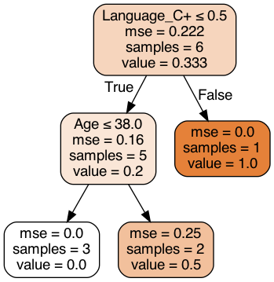

```python
Image('GboostClassifierTree.png')
```

## D. Updating rule

$$F_m(x) = F_{m-1}(x) + \nu \sum_{j=1}^{J_m} \gamma_{jm}I(x \in R_{jm})$$

where: $\nu$: our learning rate

#### Sum up all the output values $\gamma_{jm}$ for all the leaves that our x can be found in or is a member of.

$$\sum_{j=1}^{J_m} \gamma_{jm}I(x \in R_{jm})$$

#### Update Prediction By Combining Leaf With New Tree

$$\begin{array}{c|c} Masters & Age & Language & Accepted & Residuals & Leaf\\ \hline {\color{orange}{Yes}} & {\color{orange}{22}} & {\color{orange}{Python}} & {\color{orange}{Yes}} & {\color{orange}{0.333}}& {\color{orange}{\text{Bottom Left}}}\\ \hline Yes & 57 & R &Yes& 0.333& \text{Bottom Right}\\ \hline No & 44 & Python &No& -0.667& \text{Bottom Right}\\ \hline {\color{blue}{Yes}} & {\color{blue}{29}} & {\color{blue}{C+}} & {\color{blue}{No}} & {\color{blue}{-0.667}}& {\color{blue}{\text{Top Right}}}\\ \hline {\color{orange}{No}} & {\color{orange}{32}} & {\color{orange}{R}} & {\color{orange}{Yes}} & {\color{orange}{0.333}}& {\color{orange}{\text{Bottom Left}}}\\ \hline {\color{orange}{No}} & {\color{orange}{24}} & {\color{orange}{Python}} & {\color{orange}{Yes}} & {\color{orange}{0.333}}& {\color{orange}{\text{Bottom Left}}} \end{array}$$

Person in Blue above ended on the Top Right Leaf with a value of -3 and If we add that to our initial log(odd) prediction (leaf one) with our learning rate we have:

$$ 0.6931 + 0.8(-3)$$$$\text{New log(odds) Prediction}= -1.7069$$

## Convert New Log(odds) Prediction Into A Probability

$$\frac{e^{log(odds)}}{1+e^{log(odds)}} = \frac{e^{-1.7069}}{1+e^{-1.7069}} = 0.15$$

### Small Step In the Right Direction

$$\begin{array}{c|c} Masters & Age & Language & Accepted & \text{Initial Prediction} & \text{Predicted Prob.} \\ \hline Yes & 22 & Python & Yes&0.6931& 0.87\\ \hline Yes & 57 & R & Yes & 0.6931 & 0.52\\ \hline {\color{orange}{No}} & {\color{orange}{44}} & {\color{orange}{Python}} & {\color{Red}{No}} & {\color{orange}{0.6931}} & {\color{green}{0.52}}\\ \hline {\color{orange}{Yes}} & {\color{orange}{29}} & {\color{orange}{C+}} & {\color{Red}{No}} & {\color{orange}{0.6931}} & {\color{green}{0.15}}\\ \hline No& 32 & R & Yes & 0.6931& 0.87\\ \hline No& 24& Python & Yes&0.6931 & 0.87 \end{array}$$

# Calculate New Pseudo-Residuals

The pseudo-residuals is the difference between the observed and predicted.

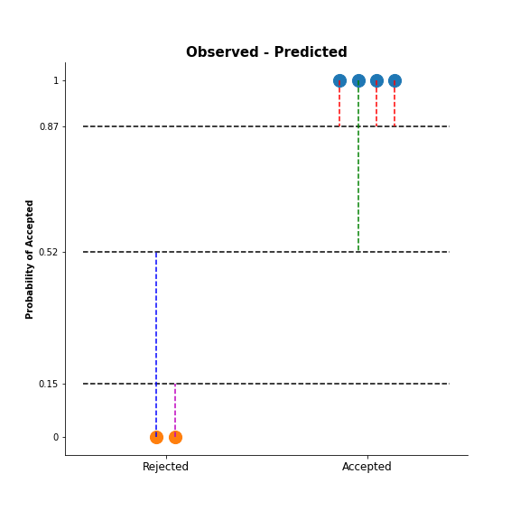

```python
Image('SecondResid.png')
```

## Variable Split (Just A Few Examples)

#### Masters_Yes

$$\begin{array}{c|c} & Masters & Residuals& Mean & (\text{Mean-Residuals})^2\\ \hline &Yes & 0.13& 0.153 & 0.000529\\ \hline &Yes &0.48 & 0.153 & 0.107\\ \hline &Yes & -0.15 & 0.153 & 0.09\\ \hline Sum & & & & 0.199\\ \hline MSE & & & & {\color{red}{0.066}} \end{array}$$

#### Masters_No

$$\text{Weighted Average} = \frac{3}{3+3}0.066+ \frac{3}{3+3}0.082 $$

$$= 0.074 $$

#### C+

$$\begin{array}{c|c} & Language & Residuals& Mean & (\text{Mean-Residuals})^2\\ \hline &C+ & -0.15 & -0.15 & 0\\ \hline Sum & & & & 0\\ \hline MSE & & & & {\color{red}{0}} \end{array}$$

#### Other

$$\text{Weighted Average} = \frac{1}{1+0}0+ \frac{5}{5+1}0.095 $$

$$= 0.079 $$

#### 50.5 $\geq$

$$\begin{array}{c|c} & Age & Residuals& Mean & (\text{Mean-Residuals})^2\\ \hline &57 & 0.48 & 0.48 & 0\\ \hline Sum & & & & 0\\ \hline MSE & & & & {\color{red}{0}} \end{array}$$

#### 50.5 $\leq$

$$\text{Weighted Average} = \frac{1}{1+5}0+ \frac{5}{5+1}0.058 $$

$$= 0.048 $$

## Decision For our Root Node:

### 50.5 $\leq$

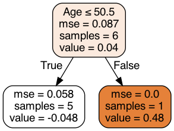

```python
Image('SecondRootTree.png')
```

# Predictions vs Probability

Our Predictions are in terms of log(odds) while our leaves are derived from probabilities so we can't just add them without a transformation

### Classification Formula for Transforming Leaf Values

$$\frac{\sum{}{}Residual_i}{\sum_{}{}[\text{Previous $Probability_i$ x (1 -Previous $Probability_i$) }]}$$

$$\text{Sum of All Observation Residuals in the Leaf} = \sum{}{}Residual_i$$

$$\text{Sum of the Previously Predicted Probabilities for Each Residual} = \sum_{}{}[\text{Previous $Probability_i$ x (1 -Previous $Probability_i$)}]$$

#### Top Right Leaf

$$\frac{0.48}{0.52 \times (1 - 0.52)} = 1.92$$

#### Bottom Right Leaf

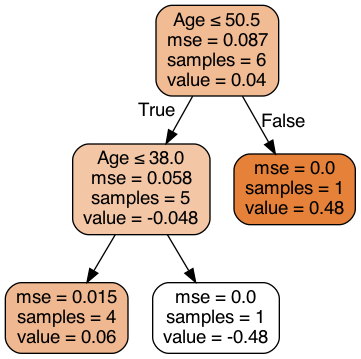

```python
Image('SecondFullTree.png')
```

## Update Prediction By Combining Leaf With First and Second Tree

$$ 0.6931 + 0.8(-3) + 0.8(0.514)$$$$\text{New log(odds) Prediction}= -1.2957$$

## Convert New Log(odds) Prediction Into A Probability

$$\frac{e^{log(odds)}}{1+e^{log(odds)}} = \frac{e^{-1.2957}}{1+e^{-1.2957}} = 0.21$$

### Small Step In the Right Direction

# Prediction Using Only The Above Forest

$$\begin{array}{c|c} Masters & Age & Language & Accepted\\ \hline Yes & 26 & R & ? \end{array}$$

## Using a Threshold of 0.5

$$\begin{array}{c|c} Masters & Age & Language & Accepted\\ \hline Yes & 26 & R & YES \end{array}$$

# Appendix

**Library**:

```
import numpy as np
import matplotlib.pyplot as plt
from sklearn.metrics import r2_score
from sklearn.model_selection import GridSearchCV
from sklearn.datasets import make_regression
import matplotlib.lines as mlines
from sklearn.model_selection import train_test_split
from sklearn.metrics import confusion_matrix,accuracy_score
from sklearn.tree import DecisionTreeClassifier, DecisionTreeRegressor
import seaborn as sns
import pandas as pd
import scipy
from IPython.display import display
from IPython.display import Image
from sklearn.datasets import make_regression
from sklearn import tree
import graphviz
from sklearn.ensemble import RandomForestClassifier, RandomForestRegressor
from sklearn.ensemble import VotingClassifier
from sklearn.linear_model import LogisticRegression
from sklearn.svm import SVC
from sklearn.ensemble import BaggingClassifier
from mlxtend.plotting import plot_decision_regions
```

**LogView**:

```
from matplotlib.pyplot import sca
# create two classes
x1 = [0.7,0.75,0.8,0.85]
y1 = [1,1,1,1]

x2 = [0.2,0.25]
y2 = [0,0]

# Select length of axes and the space between tick labels


# Plot points
fig,ax1= plt.subplots(figsize=(8,8))
plt.setp(ax1, xticks=[0.225,0.775], xticklabels=['Rejected','Accepted'],
        yticks=[0,0.667, 1], yticklabels=[0,0.667,1])
ax1.scatter(x1,y1, c = 'tab:blue')
ax1.scatter(x2,y2, c = 'tab:orange')

ax1.plot([0,1],[0.667,0.667],'black',linestyle = '--')

# Remove top and right spines
ax1.spines['top'].set_visible(False)
ax1.spines['right'].set_visible(False)

# Providing subplots with titles
ax1.set_title('Observed - Predicted',fontweight="bold", size = 15)
ax1.set_ylabel('Probability of Accepted', fontdict=dict(weight='bold'))
ax1.xaxis.set_tick_params(labelsize = 12)

fig.savefig('logLikelihood.png')
```

**Root Node**

```
# creating a dataframe
boost_classifier = pd.DataFrame({'Masters':['Yes','Yes','No','Yes','No','No'],'Age':[22,57,44,29,32,24],
                          'Language': ['Python','R','Python','C+','R','Python'],'Accepted': [1,1,0,0,1,1]})

# Our Dependant variable is continuous so we calculate average weight
logOdds = (np.exp(np.log(4/2))/(1+np.exp(np.log(4/2))))

# residual (Observed - Predicted)
boost_classifier['Residual'] = boost_classifier['Accepted'] - logOdds

boost_classifier['Residual'] = np.where(boost_classifier['Residual']>0,0,1)

#boost_classifier


dummy_boost = pd.get_dummies(boost_classifier)
X = dummy_boost.drop(['Accepted','Residual'],axis=1).values
y = dummy_boost['Residual'].values
fn = dummy_boost.columns[[0,3,4,5,6,7]]
rf_clf = DecisionTreeClassifier(max_depth = 1)
rf_clf = rf_clf.fit(X,y)

dot_data = tree.export_graphviz(rf_clf, out_file=None,
                     feature_names= fn,
                     filled=True, rounded=True,
                    special_characters=True)
t = graphviz.Source(dot_data)

t.format = 'png'
t.filename = 'RootNode'
t.render()
```

**log(Likelihood)**:

```
from matplotlib.pyplot import sca
# create two classes
x1 = [0.7,0.75,0.8,0.85]
y1 = [1,1,1,1]

x2 = [0.2,0.25]
y2 = [0,0]

# Select length of axes and the space between tick labels


# Plot points
fig,(ax2, ax1)= plt.subplots(1,2,figsize=(14,8))
plt.setp(ax1, xticks=[0.225,0.775], xticklabels=['Rejected','Accepted'],
        yticks=[0,0.666, 1], yticklabels=[0,0.66,1])
ax1.scatter(x1,y1, c = 'tab:blue')
ax1.scatter(x2,y2, c = 'tab:orange')

ax1.plot([0,1],[0.666,0.666],'black',linestyle = '--')
#ax1.plot([5,1],[1.55,2.85],'m--')

ax1.plot([0.7,0.7],[1,0.666],'r--')
ax1.plot([0.75,0.75],[1,0.666],'r--')
ax1.plot([0.8,0.8],[1,0.666],'r--')
ax1.plot([0.85,0.85],[1,0.666],'r--')

ax1.plot([0.2,0.2],[0,0.666],'m--')
ax1.plot([0.25,0.25],[0,0.666],'m--')



# Remove top and right spines
ax1.spines['top'].set_visible(False)
ax1.spines['right'].set_visible(False)

# Providing subplots with titles
ax1.set_title('Observed - Predicted',fontweight="bold", size = 15)
ax1.set_ylabel('Probability of Accepted', fontdict=dict(weight='bold'))
ax1.xaxis.set_tick_params(labelsize = 12)
#___________________________________________

plt.setp(ax2, xticks=[0.225,0.775], xticklabels=['Rejected','Accepted'],
        yticks=[0,0.666, 1], yticklabels=[0,0.66,1])
ax2.scatter(x1,y1, c = 'tab:blue')
ax2.scatter(x2,y2, c = 'tab:orange')

ax2.plot([0,1],[0.666,0.666],'black',linestyle = '--')


# Remove top and right spines
ax2.spines['top'].set_visible(False)
ax2.spines['right'].set_visible(False)

# Providing subplots with titles
ax2.set_title('Residuals Intuition',fontweight="bold", size = 15)
ax2.set_ylabel('Probability of Accepted', fontdict=dict(weight='bold'))

ax2.xaxis.set_tick_params(labelsize = 12)

fig.savefig('GBLogreg.png')
```

**Feature Node**:

```
# creating a dataframe
boost_classifier = pd.DataFrame({'Masters':['Yes','Yes','No','Yes','No','No'],'Age':[22,57,44,29,32,24],
                          'Language': ['Python','R','Python','C+','R','Python'],'Accepted': [1,1,0,0,1,1]})

# Our Dependant variable is continuous so we calculate average weight
logOdds = (np.exp(np.log(4/2))/(1+np.exp(np.log(4/2))))

# residual (Observed - Predicted)
boost_classifier['Residual'] = boost_classifier['Accepted'] - logOdds

boost_classifier['Residual'] = np.where(boost_classifier['Residual']>0,0,1)

#boost_classifier


dummy_boost = pd.get_dummies(boost_classifier)
X = dummy_boost.drop(['Accepted','Residual'],axis=1).values
y = dummy_boost['Residual'].values
fn = dummy_boost.columns[[0,3,4,5,6,7]]
rf_clf = DecisionTreeClassifier(max_leaf_nodes = 3)
rf_clf = rf_clf.fit(X,y)

dot_data = tree.export_graphviz(rf_clf, out_file=None,
                     feature_names= fn,
                     filled=True, rounded=True,
                    special_characters=True)
g = graphviz.Source(dot_data)

g.format = 'png'
g.filename = 'Root'
g.render()
```

**Second Residual**:

```
from matplotlib.pyplot import sca
# create two classes
x1 = [0.7,0.75,0.8,0.85]
y1 = [1,1,1,1]

x2 = [0.2,0.25]
y2 = [0,0]

# Select length of axes and the space between tick labels


# Plot points
fig,ax1= plt.subplots(figsize=(8,8))
plt.setp(ax1, xticks=[0.225,0.775], xticklabels=['Rejected','Accepted'],
        yticks=[0,0.15,0.52,0.87, 1], yticklabels=[0,0.15,0.52,0.87, 1])
ax1.scatter(x1,y1, c = 'tab:blue')
ax1.scatter(x2,y2, c = 'tab:orange')

ax1.plot([0,1],[0.87,0.87],'black',linestyle = '--')
ax1.plot([0,1],[0.52,0.52],'black',linestyle = '--')
ax1.plot([0,1],[0.15,0.15],'black',linestyle = '--')

ax1.plot([0.7,0.7],[1,0.87],'r--')
ax1.plot([0.75,0.75],[1,0.52],'g--')
ax1.plot([0.8,0.8],[1,0.87],'r--')
ax1.plot([0.85,0.85],[1,0.87],'r--')

ax1.plot([0.2,0.2],[0,0.52],'b--')
ax1.plot([0.25,0.25],[0,0.15],'m--')



# Remove top and right spines
ax1.spines['top'].set_visible(False)
ax1.spines['right'].set_visible(False)

# Providing subplots with titles
ax1.set_title('Observed - Predicted',fontweight="bold", size = 15)
ax1.set_ylabel('Probability of Accepted', fontdict=dict(weight='bold'))
ax1.xaxis.set_tick_params(labelsize = 12)

fig.savefig('SecondResid.png')
```

**Full Tree**:

```
# creating a dataframe
boost_classifier = pd.DataFrame({'Masters':['Yes','Yes','No','Yes','No','No'],'Age':[22,57,44,29,32,24],
                          'Language': ['Python','R','Python','C+','R','Python'],'Accepted': [1,1,0,0,1,1]})

# Our Dependant variable is continuous so we calculate average weight
logOdds = (np.exp(np.log(4/2))/(1+np.exp(np.log(4/2))))

# residual (Observed - Predicted)
boost_classifier['Residual'] = boost_classifier['Accepted'] - logOdds

boost_classifier['Residual'] = np.where(boost_classifier['Residual']>0,0,1)

#boost_classifier


dummy_boost = pd.get_dummies(boost_classifier)
X = dummy_boost.drop(['Accepted','Residual'],axis=1).values
y = dummy_boost['Residual'].values
fn = dummy_boost.columns[[0,3,4,5,6,7]]
rf_clf = DecisionTreeRegressor(max_leaf_nodes = 3)
rf_clf = rf_clf.fit(X,y)

dot_data = tree.export_graphviz(rf_clf, out_file=None,
                     feature_names= fn,
                     filled=True, rounded=True,
                    special_characters=True)
z = graphviz.Source(dot_data)

z.format = 'png'
z.filename = 'GboostClassifierTree'
z.render()
```

**Second Root**:

```
# creating a dataframe
boost_classifier = pd.DataFrame({'Masters':['Yes','Yes','No','Yes','No','No'],'Age':[22,57,44,29,32,24],
                          'Language': ['Python','R','Python','C+','R','Python'],'Accepted': [1,1,0,0,1,1],
                               "Residuals":[0.13,0.48,-0.48,-0.15,0.13,0.13]})
dummy_boost = pd.get_dummies(boost_classifier)
X = dummy_boost.drop(['Accepted','Residuals'],axis=1).values
y = dummy_boost['Residuals'].values

X = X[:,[0]]
fn = dummy_boost.columns[[0]]
clf = DecisionTreeRegressor(max_depth = 1)
clf = clf.fit(X,y)

dot_data = tree.export_graphviz(clf, out_file=None,
                     feature_names= fn,
                    filled=True, rounded=True,
                    special_characters=True)
h = graphviz.Source(dot_data)


h.format = 'png'
h.filename = 'SecondRootTree'
h.render()
```